# 📊 Amazon Sales Report - Data Analysis & Business Insights

# **TASK-04**

# Customer Segmentation:

Segment customers based on their buying behaviour, location, and other relevant factors.

## Step 1: State-wise Summary – Orders, Quantity, Sales, AOV

```python
state_summary = df.groupby('ship-state').agg(
    Total_Orders=('Order ID', 'nunique'),
    Total_Quantity=('Qty', 'sum'),
    Total_Sales=('Amount', 'sum')
)
state_summary['Avg_Order_Value'] = state_summary['Total_Sales'] / state_summary['Total_Orders']
state_summary = state_summary.sort_values(by='Total_Sales', ascending=False)
state_summary.head(10)
```

| ship-state | Total_Orders | Total_Quantity | Total_Sales | Avg_Order_Value |
| --- | --- | --- | --- | --- |
| MAHARASHTRA | 20756 | 20338 | 13340333.05 | 642.721770 |
| KARNATAKA | 16162 | 15901 | 10480694.22 | 648.477554 |
| TELANGANA | 10394 | 10253 | 6915018.08 | 665.289405 |
| UTTAR PRADESH | 10057 | 9507 | 6823947.08 | 678.527104 |
| TAMIL NADU | 10507 | 10416 | 6519182.30 | 620.460864 |
| DELHI | 6347 | 6151 | 4232738.97 | 666.888131 |
| KERALA | 6097 | 5805 | 3823559.58 | 627.121466 |
| WEST BENGAL | 5645 | 5316 | 3507212.82 | 621.295451 |
| ANDHRA PRADESH | 4970 | 4816 | 3217859.86 | 647.456712 |
| HARYANA | 4134 | 4062 | 2880355.99 | 696.747941 |

## Step 2: Quantity Behavior – Total and Average Quantity per Order

```python
qty_stats = df.groupby('ship-state').agg(
    Total_Quantity=('Qty', 'sum'),
    Average_Qty_Per_Order=('Qty', 'mean')
).sort_values(by='Total_Quantity', ascending=False)

qty_stats.head(10)
```

| ship-state | Total_Quantity | Average_Qty_Per_Order |
| --- | --- | --- |
| MAHARASHTRA | 20338 | 0.913165 |
| KARNATAKA | 15901 | 0.917860 |
| TAMIL NADU | 10416 | 0.906685 |
| TELANGANA | 10253 | 0.904943 |
| UTTAR PRADESH | 9507 | 0.893011 |
| DELHI | 6151 | 0.907495 |
| KERALA | 5805 | 0.882621 |
| WEST BENGAL | 5316 | 0.891647 |
| ANDHRA PRADESH | 4816 | 0.887415 |
| Gujarat | 4142 | 0.924141 |

## Step 3: Return % and Success % by State

```python
returns = df[df['Status'] == 'Shipped - Returned to Seller']
delivered = df[df['Status'] == 'Shipped - Delivered to Buyer']

returns_state = returns.groupby('ship-state')['Order ID'].nunique()
delivered_state = delivered.groupby('ship-state')['Order ID'].nunique()
total_orders = df.groupby('ship-state')['Order ID'].nunique()

status_summary = pd.DataFrame({
    'Returns': returns_state,
    'Delivered': delivered_state,
    'Total Orders': total_orders
}).fillna(0)

status_summary['Return %'] = (status_summary['Returns'] / status_summary['Total Orders']) * 100
status_summary['Success %'] = (status_summary['Delivered'] / status_summary['Total Orders']) * 100
status_summary = status_summary.sort_values(by='Return %', ascending=False)
status_summary.head(10)
```

| ship-state | Returns | Delivered | Total Orders | Return % | Success % |
| --- | --- | --- | --- | --- | --- |
| Bihar | 3.0 | 4.0 | 27 | 11.111111 | 14.814815 |
| Chandigarh | 1.0 | 2.0 | 11 | 9.090909 | 18.181818 |
| delhi | 1.0 | 3.0 | 17 | 5.882353 | 17.647059 |
| LADAKH | 2.0 | 5.0 | 42 | 4.761905 | 11.904762 |
| Odisha | 1.0 | 2.0 | 21 | 4.761905 | 9.523810 |
| ASSAM | 59.0 | 344.0 | 1601 | 3.685197 | 21.486571 |
| SIKKIM | 6.0 | 37.0 | 194 | 3.092784 | 19.072165 |
| JHARKHAND | 41.0 | 305.0 | 1381 | 2.968863 | 22.085445 |
| MIZORAM | 2.0 | 7.0 | 71 | 2.816901 | 9.859155 |
| JAMMU & KASHMIR | 18.0 | 156.0 | 669 | 2.690583 | 23.318386 |

## Step 4: Return-Prone States Summary Table

```python
combined_return_order = pd.DataFrame({
    'Total_Orders': df['ship-state'].value_counts(),
    'Return_Orders': returns['ship-state'].value_counts()
}).fillna(0)

combined_return_order['Return_Rate_%'] = (combined_return_order['Return_Orders'] / combined_return_order['Total_Orders']) * 100
combined_return_order = combined_return_order.sort_values(by='Return_Rate_%', ascending=False)
combined_return_order.head(10)
```

| ship-state | Total_Orders | Return_Orders | Return_Rate_% |
| --- | --- | --- | --- |
| Bihar | 27 | 3.0 | 11.111111 |
| Chandigarh | 11 | 1.0 | 9.090909 |
| Odisha | 21 | 1.0 | 4.761905 |
| delhi | 21 | 1.0 | 4.761905 |
| LADAKH | 43 | 2.0 | 4.651163 |
| MIZORAM | 75 | 3.0 | 4.000000 |
| ASSAM | 1664 | 60.0 | 3.605769 |
| JHARKHAND | 1457 | 46.0 | 3.157172 |
| SIKKIM | 202 | 6.0 | 2.970297 |
| JAMMU & KASHMIR | 702 | 20.0 | 2.849003 |

## Step 5: Sales Distribution (Top 10 States + Others)

```python
top10_states_sales = state_summary['Total_Sales'].head(10)
others_sales = state_summary['Total_Sales'].iloc[10:].sum()
final_sales_pie = pd.concat([top10_states_sales, pd.Series({'Others': others_sales})])

# 👇 Show the output
final_sales_pie
```

```
MAHARASHTRA       13340333.05
KARNATAKA         10480694.22
TELANGANA          6915018.08
UTTAR PRADESH      6823947.08
TAMIL NADU         6519182.30
DELHI              4232738.97
KERALA             3823559.58
WEST BENGAL        3507212.82
ANDHRA PRADESH     3217859.86
HARYANA            2880355.99
Others            16829646.30
dtype: float64
```

## Step 6: Show Correlation

```python
correlation_check = combined_return_order[combined_return_order['Total_Orders'] >= 100]
correlation = correlation_check[['Total_Orders', 'Return_Rate_%']].corr()
print("📊 Correlation Between Total Orders & Return Rate:")
print(correlation)
```

```
📊 Correlation Between Total Orders & Return Rate:
               Total_Orders  Return_Rate_%
Total_Orders       1.000000      -0.314431
Return_Rate_%     -0.314431       1.000000
```

# VISUALIZATIONS

## Chart 1: Top 10 States by Order Count

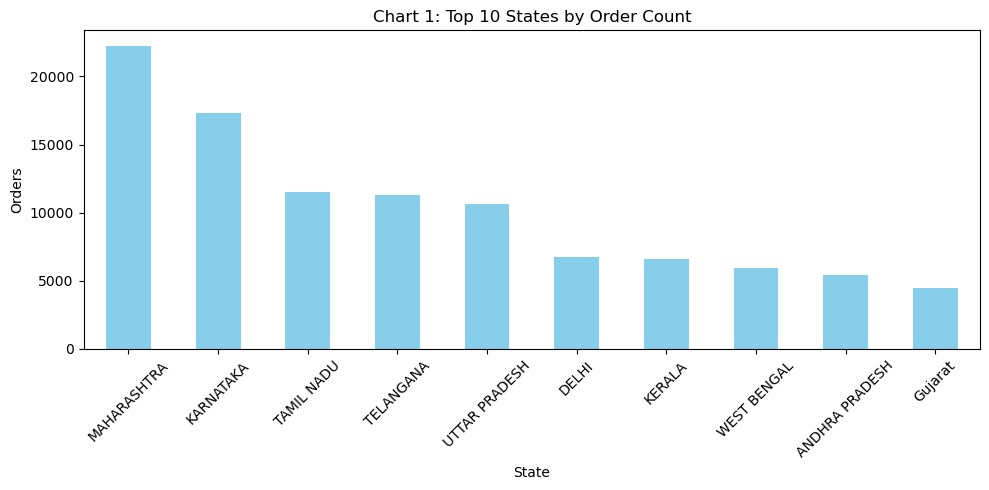

```python
plt.figure(figsize=(10, 5))
df['ship-state'].value_counts().head(10).plot(kind='bar', color='skyblue')
plt.title("Chart 1: Top 10 States by Order Count")
plt.xlabel("State")
plt.ylabel("Orders")
plt.xticks(rotation=45)
plt.tight_layout()
plt.show()
```

## Chart 2: Top 10 States by Total Sales

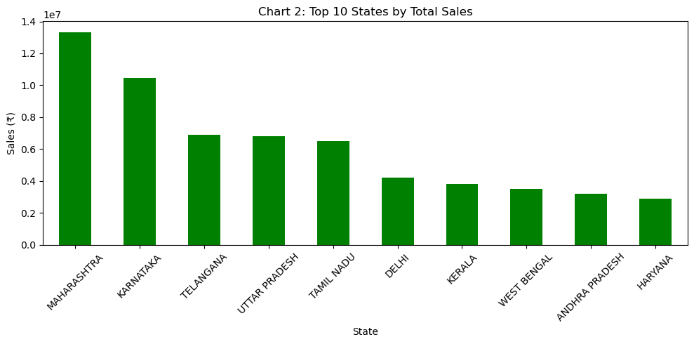

```python
plt.figure(figsize=(10, 5))
state_summary['Total_Sales'].head(10).plot(kind='bar', color='green')
plt.title("Chart 2: Top 10 States by Total Sales")
plt.xlabel("State")
plt.ylabel("Sales (₹)")
plt.xticks(rotation=45)
plt.tight_layout()
plt.show()
```

## Chart 3: Top 10 States by Quantity Ordered

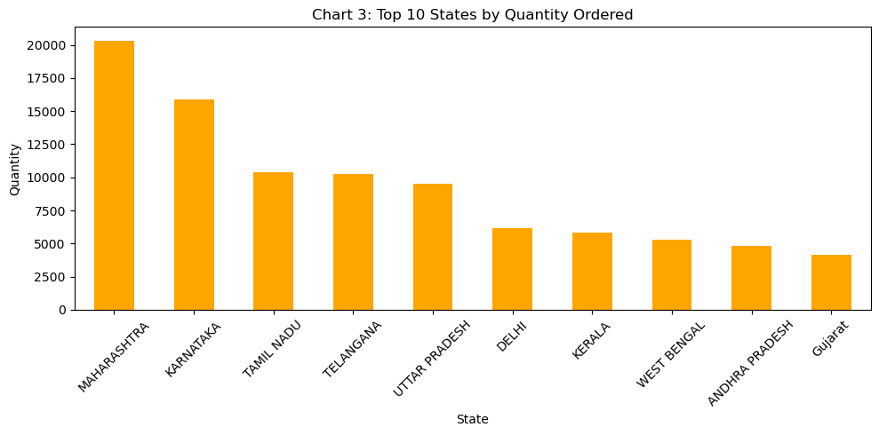

```python
plt.figure(figsize=(10, 5))
qty_stats['Total_Quantity'].head(10).plot(kind='bar', color='orange')
plt.title("Chart 3: Top 10 States by Quantity Ordered")
plt.xlabel("State")
plt.ylabel("Quantity")
plt.xticks(rotation=45)
plt.tight_layout()
plt.show()
```

## Chart 4: Top 10 Return-Prone States

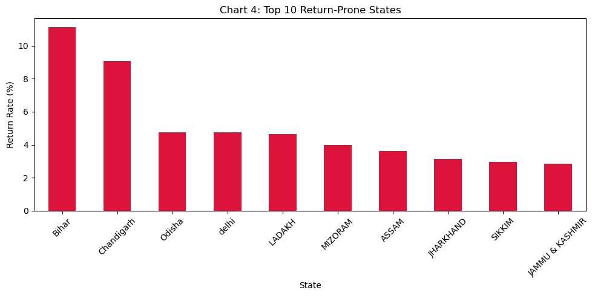

```python
plt.figure(figsize=(10, 5))
combined_return_order['Return_Rate_%'].head(10).plot(kind='bar', color='crimson')
plt.title("Chart 4: Top 10 Return-Prone States")
plt.xlabel("State")
plt.ylabel("Return Rate (%)")
plt.xticks(rotation=45)
plt.tight_layout()
plt.show()
```

## Chart 5: Sales Distribution by Top 10 States

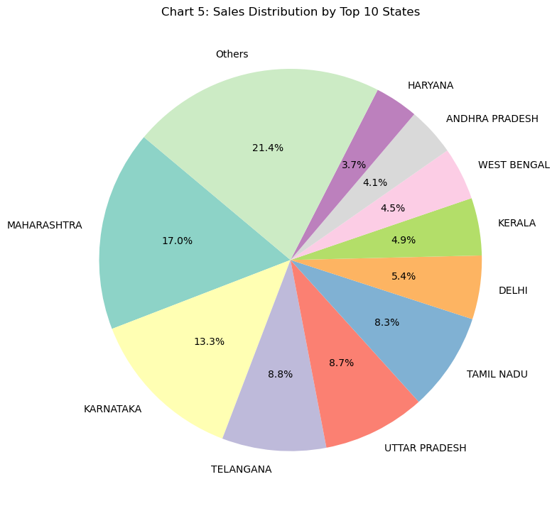

```python
plt.figure(figsize=(8, 8))
plt.pie(
    final_sales_pie,
    labels=final_sales_pie.index,
    autopct='%1.1f%%',
    startangle=140,
    colors=sns.color_palette('Set3'),
    textprops={'fontsize': 10}
)
plt.title("Chart 5: Sales Distribution by Top 10 States")
plt.tight_layout()
plt.show()
```

# ✅ Conclusion

- 📍 Maharashtra and Karnataka dominate in total orders and revenue.
- 💰 Average Order Value is consistent across top-performing states.
- 🔁 High return rates are observed in smaller states like Bihar and Ladakh — which may indicate issues in logistics or communication.
- 🌐 Segmentation based on location and behavior helps create personalized marketing strategies.

# **TASK-05**

# Geographical Analysis:

Explore the geographical distribution of sales, focusing on states and cities.

## Step 1: Rename Columns for Clean Code

```python
df.rename(columns={'ship-city': 'City', 'ship-state': 'State'}, inplace=True)
print("✅ Columns renamed to 'City' and 'State'")
```

```
✅ Columns renamed to 'City' and 'State'
```

## Step 2: Drop Missing Location Data

```python
# Check and drop missing
missing_location = df[['State', 'City']].isnull().sum()
print("Missing values before drop:\n", missing_location)

df = df.dropna(subset=['State', 'City'])

print(f"✅ Missing rows dropped. Remaining rows: {len(df)}")
```

```
Missing values before drop:
 State    35
City     35
dtype: int64
✅ Missing rows dropped. Remaining rows: 128941
```

## Step 3: Total Sales by State

```python
state_sales = df.groupby('State')['Amount'].sum().sort_values(ascending=False)
print("🏆 Top 10 States by Total Sales:\n", state_sales.head(10))
```

```
🏆 Top 10 States by Total Sales:
 State
MAHARASHTRA       13340333.05
KARNATAKA         10480694.22
TELANGANA          6915018.08
UTTAR PRADESH      6823947.08
TAMIL NADU         6519182.30
DELHI              4232738.97
KERALA             3823559.58
WEST BENGAL        3507212.82
ANDHRA PRADESH     3217859.86
HARYANA            2880355.99
Name: Amount, dtype: float64
```

## Step 4: Total Sales by City

```python
city_sales = df.groupby('City')['Amount'].sum().sort_values(ascending=False)
print("🏙️ Top 10 Cities by Total Sales:\n", city_sales.head(10))
```

```
🏙️ Top 10 Cities by Total Sales:
 City
BENGALURU    6845390.65
HYDERABAD    4946394.25
MUMBAI       3701843.04
NEW DELHI    3612512.78
CHENNAI      3103415.74
PUNE         2342011.18
KOLKATA      1413603.87
GURUGRAM     1220562.74
THANE        1004503.29
LUCKNOW       938076.34
Name: Amount, dtype: float64
```

## Step 5: Average Order Value by State

```python
state_avg_order = df.groupby('State')['Amount'].mean().sort_values(ascending=False)
print("📈 Top 10 States by Avg. Order Value:\n", state_avg_order.head(10))
```

```
📈 Top 10 States by Avg. Order Value:
 State
bihar          1432.000000
LADAKH          914.010238
Sikkim          901.000000
delhi           827.681000
Chandigarh      823.147273
NAGALAND        801.288659
LAKSHADWEEP     793.822500
SIKKIM          738.639893
Mizoram         735.000000
Punjab          733.766667
Name: Amount, dtype: float64
```

## Step 6: Number of Orders by City

```python
city_order_count = df['City'].value_counts().head(10)
print("📦 Top 10 Cities by Order Count:\n", city_order_count)
```

```
📦 Top 10 Cities by Order Count:
 City
BENGALURU    11208
HYDERABAD     8077
MUMBAI        6125
NEW DELHI     5792
CHENNAI       5430
PUNE          3863
KOLKATA       2380
GURUGRAM      1865
THANE         1701
LUCKNOW       1462
Name: count, dtype: int64
```

## Step 7: State-wise % Sales Contribution

```python
top_states = state_sales.head(5)
others = state_sales.iloc[5:].sum()

# Combine using concat (not append)
sales_pie = pd.concat([top_states, pd.Series({'Others': others})])

# Calculate percentage
sales_pie_percent = (sales_pie / sales_pie.sum()) * 100

# Display result
print("📊 State-wise Sales Contribution (%):\n", sales_pie_percent.round(2))
```

```
📊 State-wise Sales Contribution (%):
 MAHARASHTRA      16.98
KARNATAKA        13.34
TELANGANA         8.80
UTTAR PRADESH     8.69
TAMIL NADU        8.30
Others           43.90
dtype: float64
```

# VISUALIZATIONS

## Chart 1: Top 10 States by Total Sales

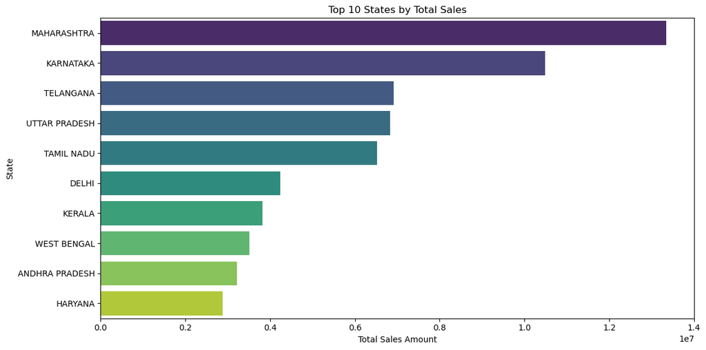

```python
plt.figure(figsize=(12, 6))
sns.barplot(x=state_sales.head(10).values, y=state_sales.head(10).index, palette='viridis')
plt.title("Top 10 States by Total Sales")
plt.xlabel("Total Sales Amount")
plt.ylabel("State")
plt.tight_layout()
plt.show()
```

## Chart 2: Top 10 Cities by Total Sales

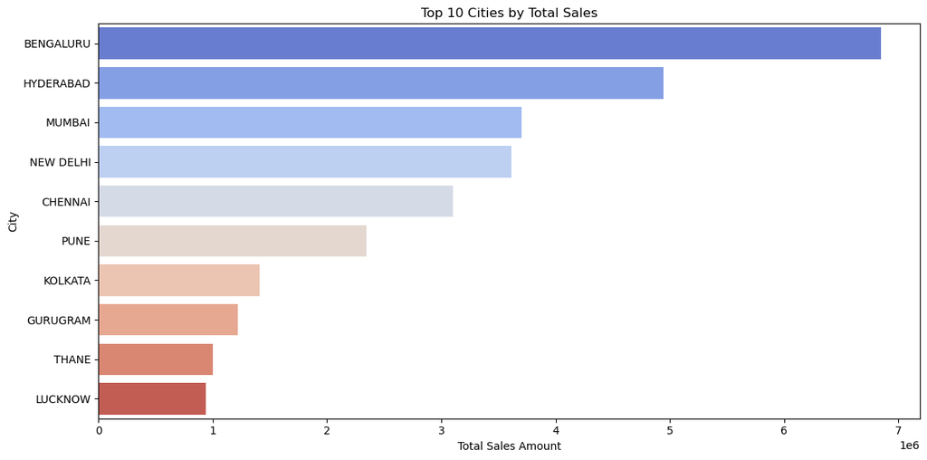

```python
plt.figure(figsize=(12, 6))
sns.barplot(x=city_sales.head(10).values, y=city_sales.head(10).index, palette='coolwarm')
plt.title("Top 10 Cities by Total Sales")
plt.xlabel("Total Sales Amount")
plt.ylabel("City")
plt.tight_layout()
plt.show()
```

## Chart 3: Top 10 States by Average Order Value

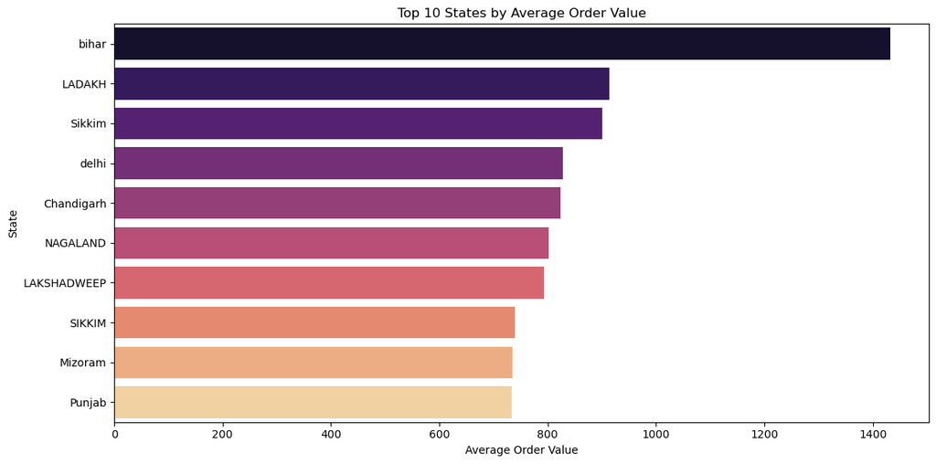

```python
plt.figure(figsize=(12, 6))
sns.barplot(x=state_avg_order.head(10).values, y=state_avg_order.head(10).index, palette='magma')
plt.title("Top 10 States by Average Order Value")
plt.xlabel("Average Order Value")
plt.ylabel("State")
plt.tight_layout()
plt.show()
```